# Lab 10

STAT 359 Data Visualization

# Overview

The goal of this lab is to continue learning data wranging (a skill which is REQUIRED for real-life analysis and data visualization) and continue combining the data visualization components which have been introduced over the previous weeks. This lab, in contrast to the previous two, will add the `gather()` function as it will be useful in creating data sets which can be easily visualized.

# Datasets

The `vgsales.csv` files are from Kaggle (https://www.kaggle.com/gregorut/videogamesales).

Per the website:

This dataset contains a list of video games with sales greater than 100,000 copies. It was generated by a scrape of vgchartz.com.

- `Rank` - Sales rank
- `Name` - Name of the game
- `Platform` - Release platform for the game
- `Year` - Year of the release
- `Genre` - Game genre
- `Publisher` - Company which released the game
- `NA_Sales` - North American sales
- `EU_Sales` - European sales
- `JP_Sales` - Japanese sales
- `Other_Sales` - Sales countries other than North America, Europe, and Japan
- `Global_Sales` - Sales from all coutries

# Task

Run the provided R code, just below, prior to completing the tasks.

Note: Appropriate styling and labeling is REQUIRED (where APPROPRIATE… remember, this is subjective).

```r
# Import libraries
library(tidyverse)
library(ggthemes)

# Import data
videogame_sales_data <- read_csv('vgsales.csv')

glimpse(videogame_sales_data)
```

```
## Observations: 16,598
## Variables: 11
## $ Rank         <int> 1, 2, 3, 4, 5, 6, 7, 8, 9, 10, 11, 12, 13, 14, 15...
## $ Name         <chr> "Wii Sports", "Super Mario Bros.", "Mario Kart Wi...
## $ Platform     <chr> "Wii", "NES", "Wii", "Wii", "GB", "GB", "DS", "Wi...
## $ Year         <chr> "2006", "1985", "2008", "2009", "1996", "1989", "...
## $ Genre        <chr> "Sports", "Platform", "Racing", "Sports", "Role-P...
## $ Publisher    <chr> "Nintendo", "Nintendo", "Nintendo", "Nintendo", "...
## $ NA_Sales     <dbl> 41.49, 29.08, 15.85, 15.75, 11.27, 23.20, 11.38, ...
## $ EU_Sales     <dbl> 29.02, 3.58, 12.88, 11.01, 8.89, 2.26, 9.23, 9.20...
## $ JP_Sales     <dbl> 3.77, 6.81, 3.79, 3.28, 10.22, 4.22, 6.50, 2.93, ...
## $ Other_Sales  <dbl> 8.46, 0.77, 3.31, 2.96, 1.00, 0.58, 2.90, 2.85, 2...
## $ Global_Sales <dbl> 82.74, 40.24, 35.82, 33.00, 31.37, 30.26, 30.01, ...
```

0a. How many distinct platforms are there in the data? (hint: use Google. There is a function just for this.)

```r
n_distinct(videogame_sales_data$Platform)
```

```
## [1] 31
```

0b. Are Global_Sales the sum of `NA_Sales`, `EU_Sales`, `JP_Sales`, and `Other Sales`? Prove it. (hint: there are many ways to accomplish this and the amounts may be off due to rounding error… one way uses `near()`, another uses `mutate()`, `select()`, and `unique()` functions, among others…)

```r
videogame_sales_data %>%
  mutate(Global_Sales_Test = NA_Sales + EU_Sales + JP_Sales + Other_Sales,
         isSame = abs(Global_Sales_Test - Global_Sales) < .5) %>%
  select(isSame) %>%
  unique()
```

```
## # A tibble: 1 x 1
##   isSame
##   <lgl>
## 1 TRUE
```

```r
# OR

videogame_sales_data %>%
  mutate(Global_Sales_Test = NA_Sales + EU_Sales + JP_Sales + Other_Sales,
         isSame = near(Global_Sales_Test, Global_Sales, .05)) %>%
  select(isSame) %>%
  unique()
```

```
## # A tibble: 1 x 1
##   isSame
##   <lgl>
## 1 TRUE
```

1a. Recreate this plot. (hint: it uses `theme_hc()`)

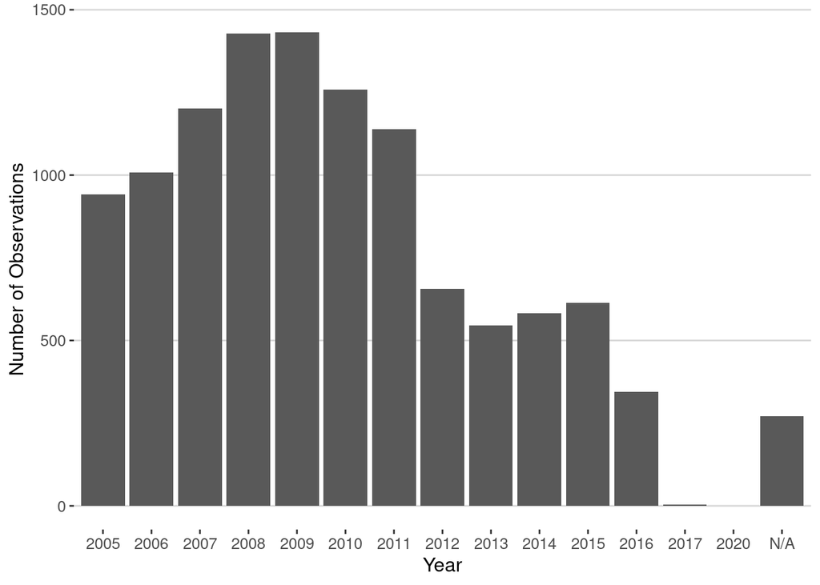

```r
sales_count_data <- filter(videogame_sales_data, Year >= 2005)

ggplot(sales_count_data, aes(Year)) +
  geom_bar() +
  theme_hc() +
  labs(y = 'Number of Observations')
```

1b. Is there anything on this visualization which would make you supicious (hint: there is)? What is it?

`1. 2020 hasn't happened yet... but, maybe these are pre-sales?` `2. Lots of NA values... what should we do with them (in real life: speak to a domain expert)?` `3. Not sure all sales are fully account in the most recent years (again: speak to a domain expert)`

2a. What’s wrong with the below dataframe? Fix it.

```r
(videogame_sales_data2 <- videogame_sales_data %>%
  gather(NA_Sales, EU_Sales, JP_Sales, Other_Sales, Global_Sales))
```

```
## # A tibble: 49,794 x 8
##     Rank Name           Platform Year  Genre   Publisher NA_Sales EU_Sales
##    <int> <chr>          <chr>    <chr> <chr>   <chr>     <chr>       <dbl>
##  1     1 Wii Sports     Wii      2006  Sports  Nintendo  JP_Sales     3.77
##  2     2 Super Mario B… NES      1985  Platfo… Nintendo  JP_Sales     6.81
##  3     3 Mario Kart Wii Wii      2008  Racing  Nintendo  JP_Sales     3.79
##  4     4 Wii Sports Re… Wii      2009  Sports  Nintendo  JP_Sales     3.28
##  5     5 Pokemon Red/P… GB       1996  Role-P… Nintendo  JP_Sales    10.2
##  6     6 Tetris         GB       1989  Puzzle  Nintendo  JP_Sales     4.22
##  7     7 New Super Mar… DS       2006  Platfo… Nintendo  JP_Sales     6.5
##  8     8 Wii Play       Wii      2006  Misc    Nintendo  JP_Sales     2.93
##  9     9 New Super Mar… Wii      2009  Platfo… Nintendo  JP_Sales     4.7
## 10    10 Duck Hunt      NES      1984  Shooter Nintendo  JP_Sales     0.28
## # ... with 49,784 more rows
```

```r
(videogame_sales_data2 <- videogame_sales_data %>%
  gather(NA_Sales, EU_Sales, JP_Sales, Other_Sales, Global_Sales, key = 'Region', value = 'Sales'))
```

```
## # A tibble: 82,990 x 8
##     Rank Name              Platform Year  Genre    Publisher Region  Sales
##    <int> <chr>             <chr>    <chr> <chr>    <chr>     <chr>   <dbl>
##  1     1 Wii Sports        Wii      2006  Sports   Nintendo  NA_Sal…  41.5
##  2     2 Super Mario Bros. NES      1985  Platform Nintendo  NA_Sal…  29.1
##  3     3 Mario Kart Wii    Wii      2008  Racing   Nintendo  NA_Sal…  15.8
##  4     4 Wii Sports Resort Wii      2009  Sports   Nintendo  NA_Sal…  15.8
##  5     5 Pokemon Red/Poke… GB       1996  Role-Pl… Nintendo  NA_Sal…  11.3
##  6     6 Tetris            GB       1989  Puzzle   Nintendo  NA_Sal…  23.2
##  7     7 New Super Mario … DS       2006  Platform Nintendo  NA_Sal…  11.4
##  8     8 Wii Play          Wii      2006  Misc     Nintendo  NA_Sal…  14.0
##  9     9 New Super Mario … Wii      2009  Platform Nintendo  NA_Sal…  14.6
## 10    10 Duck Hunt         NES      1984  Shooter  Nintendo  NA_Sal…  26.9
## # ... with 82,980 more rows
```

2b. Convert the new column contain the different sales regions into a factor variable.

```r
videogame_sales_data2 <- videogame_sales_data2 %>%
  mutate(Region = factor(Region))
```

3. Observe the below [bad] visualization using geom_boxplot and display the single largest offending outlier.

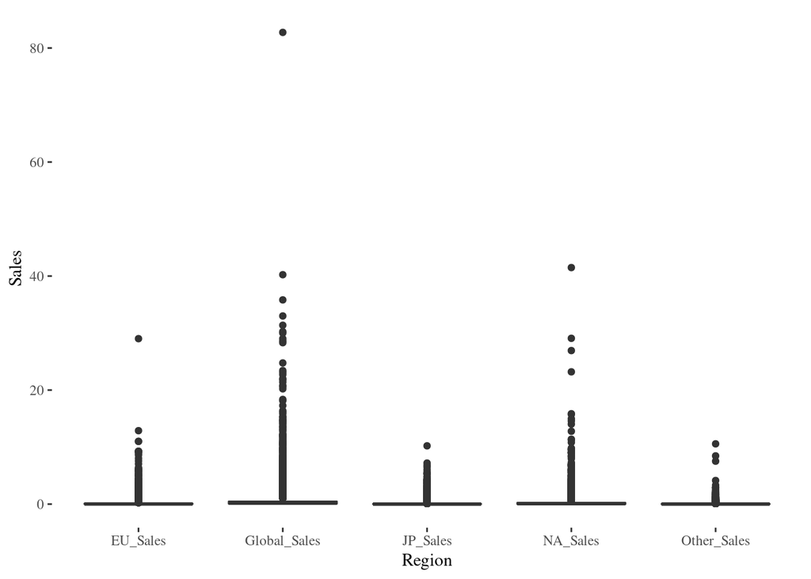

```r
ggplot(videogame_sales_data2, aes(Region, Sales)) +
  geom_boxplot() +
  theme_tufte()
```

```r
filter(videogame_sales_data2, Sales > 80)
```

```
## # A tibble: 1 x 8
##    Rank Name       Platform Year  Genre  Publisher Region       Sales
##   <int> <chr>      <chr>    <chr> <chr>  <chr>     <fct>        <dbl>
## 1     1 Wii Sports Wii      2006  Sports Nintendo  Global_Sales  82.7
```

4. Recreate the below visualization. (hint: the theme is grey)

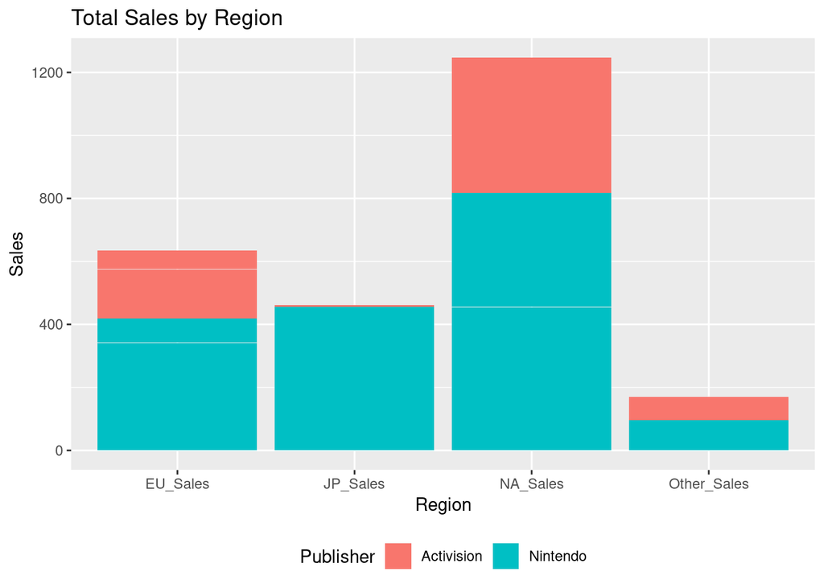

```r
Nintendo_Activision_data <- filter(videogame_sales_data2, Publisher %in% c('Nintendo', 'Activision'),
                                   Region != 'Global_Sales')

ggplot(Nintendo_Activision_data, aes(Region, Sales, fill = Publisher)) +
  geom_bar(stat = 'identity') +
  theme_grey() +
  labs(title = 'Total Sales by Region') +
  theme(legend.position = 'bottom')
```

5. Recreate the below visualization. (hint: the theme is light)

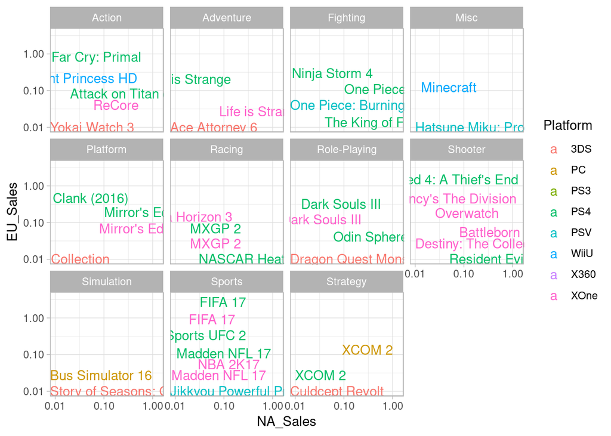

```r
year2016_data <- (filter(videogame_sales_data, Year == 2016))

ggplot(year2016_data, aes(NA_Sales, EU_Sales, label = Name, color = Platform)) +
  geom_text(check_overlap = TRUE, vjust = 'inward', hjust = 'inward') +
  facet_wrap(~ Genre) +
  scale_y_log10() +
  scale_x_log10() +
  theme_light()
```